# Введение в R

## Не только координаты. Цвета = классы

В данных mtcars много колонок (переменных). Координатами стали переменные wt и mpg, но другие переменные тоже можно использовать в визуализации.

Разделим автомобили на классы в зависимости от числа цилиндров двигателя (cyl). Каждому классу соотвествует свой цвет color:

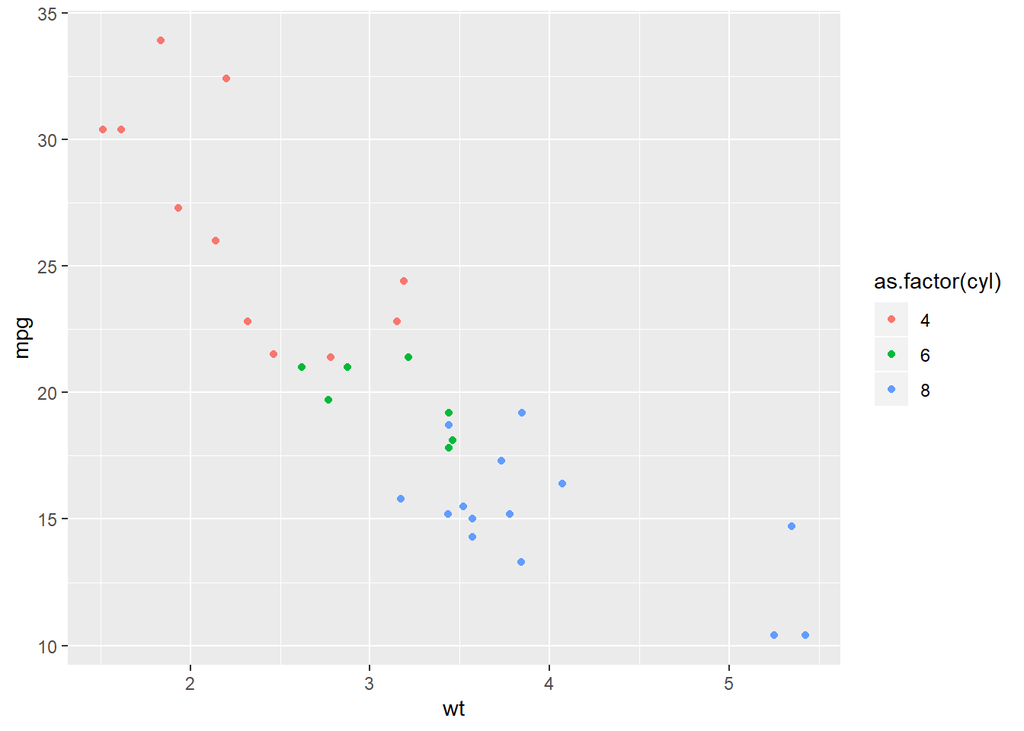

```r
ggplot(data = mtcars, mapping = aes(x = wt, y = mpg, color = as.factor(cyl))) +
  geom_point()
```

Как только мы разделили данные на классы, ggplot2 сам догадается, что сглаживать нужно каждый класс по отдельности

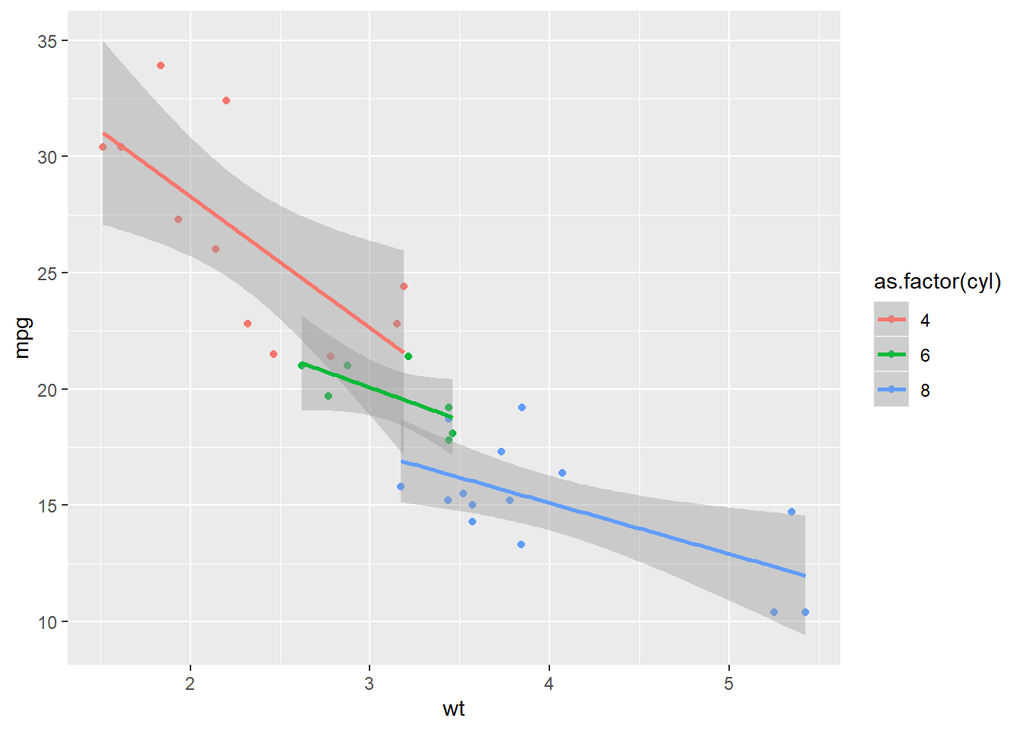

```r
ggplot(data = mtcars, mapping = aes(x = wt, y = mpg, color = as.factor(cyl))) +
  geom_point() +
  stat_smooth(method = 'lm')
```

Обратите внимание, что если не сделать переменную cyl фактором, ggplot будет считать ее непрерывной:

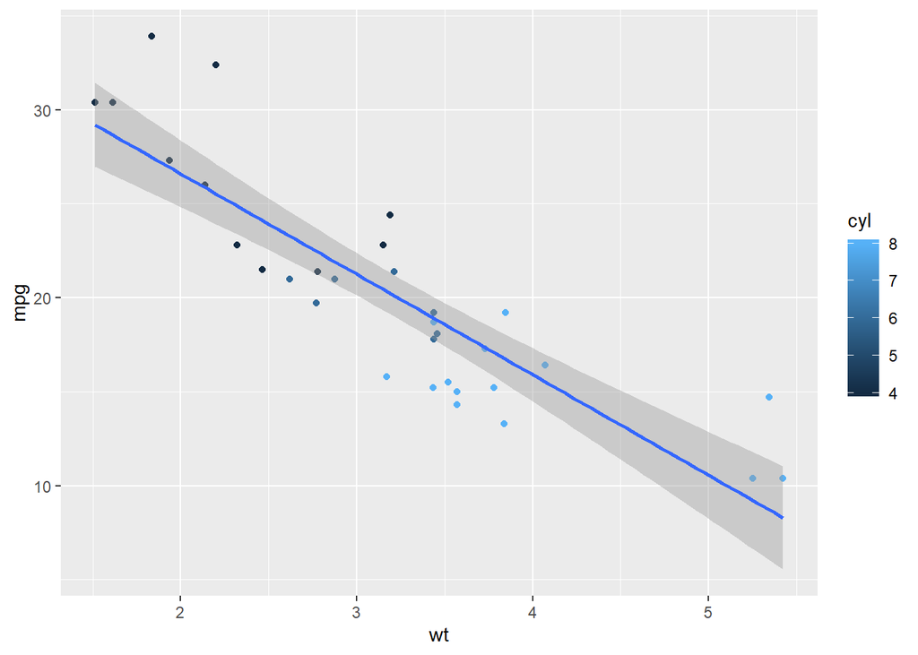

```r
ggplot(data = mtcars, mapping = aes(x = wt, y = mpg, color = cyl)) +
  geom_point() +
  stat_smooth(method = 'lm')
```

## Непрерывные переменные

Вместо факторов можно использовать непрерывные переменные. Свяжем размер точки с переменной qsec (время, за которое автомобиль проедет четверть мили):

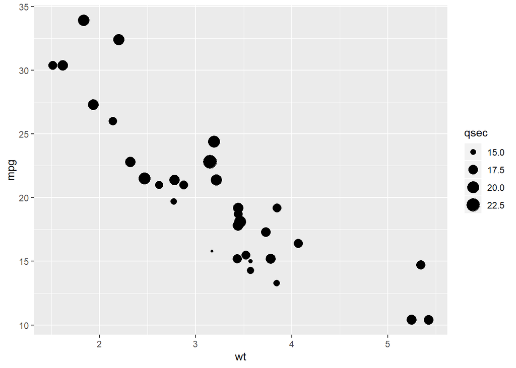

```r
ggplot(data = mtcars, mapping = aes(x = wt, y = mpg, size = qsec)) + geom_point()
```

Разделим данные на две группы: в первую поместим автомобили весом не больше 5000 фунтов, во второй — более тяжелые автомобили. Построим боксплот (“ящик с усами”). Он покажет нам информацию о медиане, квартилях и наличии выбросов.

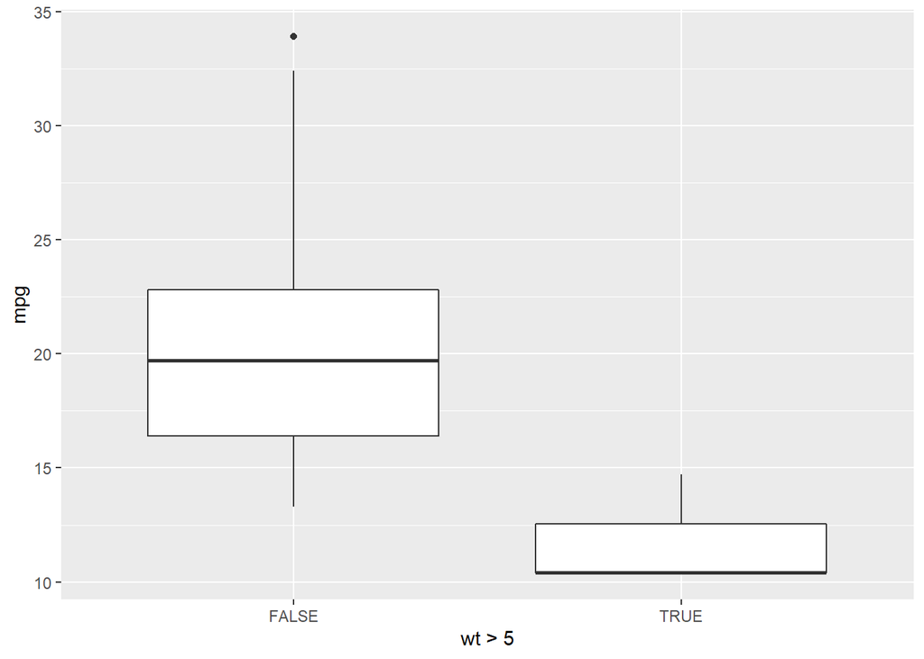

```r
ggplot(data = mtcars, mapping = aes(x = wt > 5, y = mpg)) + geom_boxplot()
```

Если вам надоели фунты, переведем их в килограммы. Чтобы подпись оси х не отображалась в виде `0.453592*wt`, применим элемент labs (подписи):

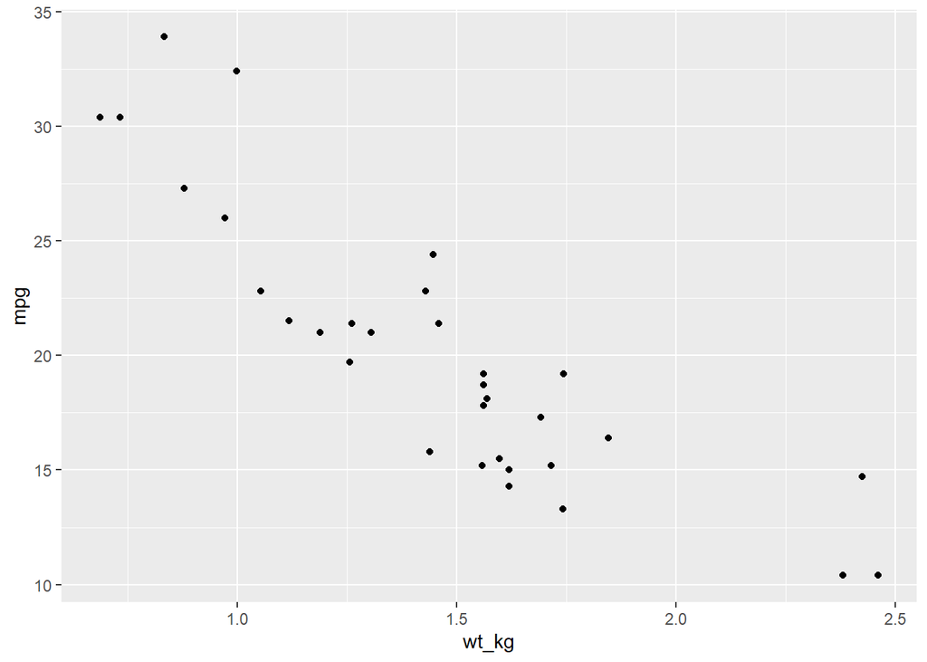

```r
ggplot(data = mtcars, mapping = aes(x = 0.453592*wt, y = mpg)) +
  labs(x = "wt_kg") + geom_point()
```

Заметим, что с aes можно связать комбинации переменных: `aes(x = column_a + column_b / column_c)`.

## Панели

Каждый класс cyl можно отобразить каждый класс в отдельной панели (facet):

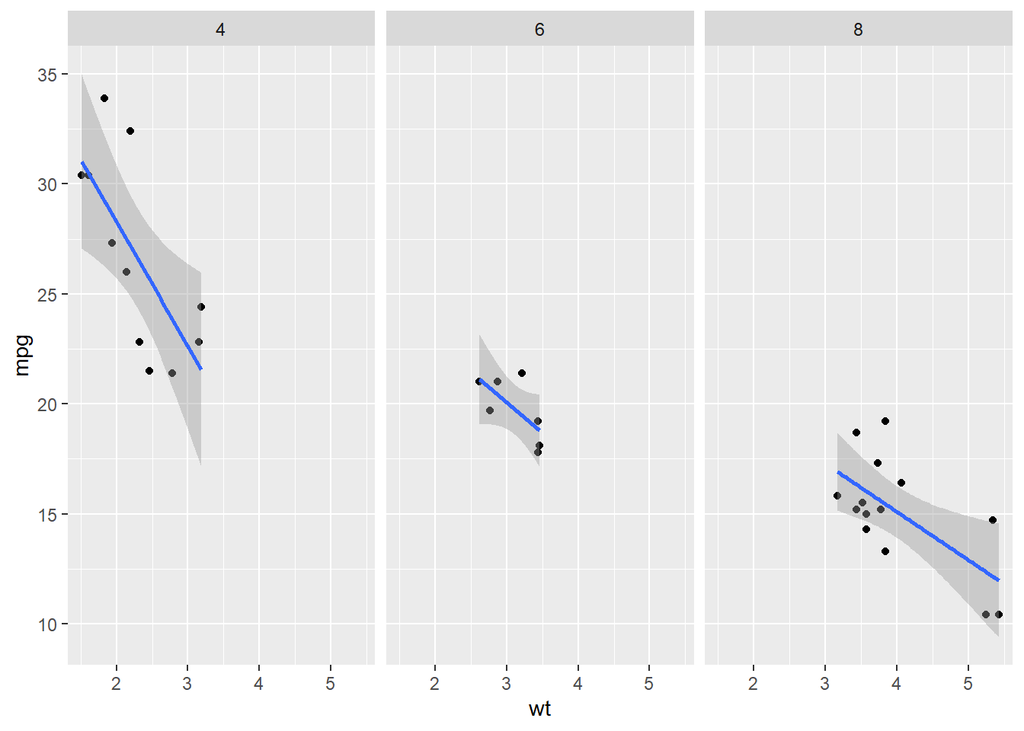

```r
ggplot(data = mtcars, mapping = aes(x = wt, y = mpg)) + geom_point() +
  stat_smooth(method = 'lm') + facet_wrap(~ cyl)
```

В заголовке панели показано число цилиндров.

Обычно оси координат одинаковы для всех панелей. В нашем случае удобно “освободить” ось x, позволив ggplot2 настроить свой интервал отображения данных для каждой панели:

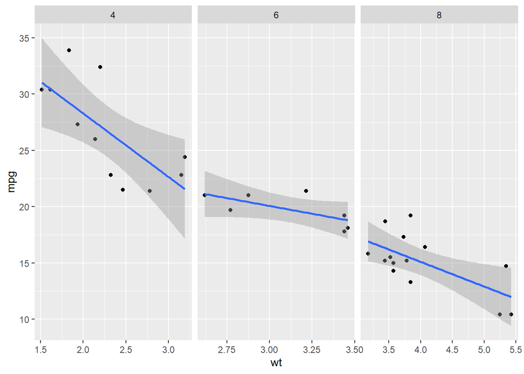

```r
ggplot(data = mtcars, mapping = aes(x = wt, y = mpg)) + geom_point() +
  stat_smooth(method = 'lm') + facet_wrap(~ cyl, scales = 'free_x')
```

scales = ‘free_x’ позволяет оси x изменяться от панели к панели.

Можно создавать панели по двум группирующим переменным. Добавим к cyl переменную am, характеризующую тип коробки передач (0 = автоматическая, 1 = ручная). Вместо facet_wrap потребуется facet_grid:

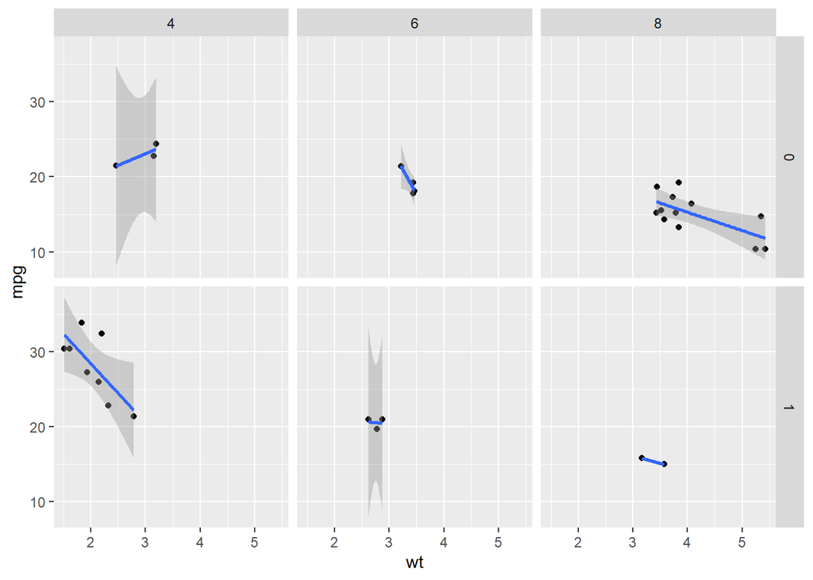

```r
ggplot(data = mtcars, mapping = aes(x = wt, y = mpg)) + geom_point() +
  stat_smooth(method = 'lm') + facet_grid(am ~ cyl)
```

Панели создаются для всех уникальных комбинаций cyl и am.

## Координатные системы

Координатная система по умолчанию — декартова (coord_cartesian). Можем заменить ее на полярные координаты (coord_polar):

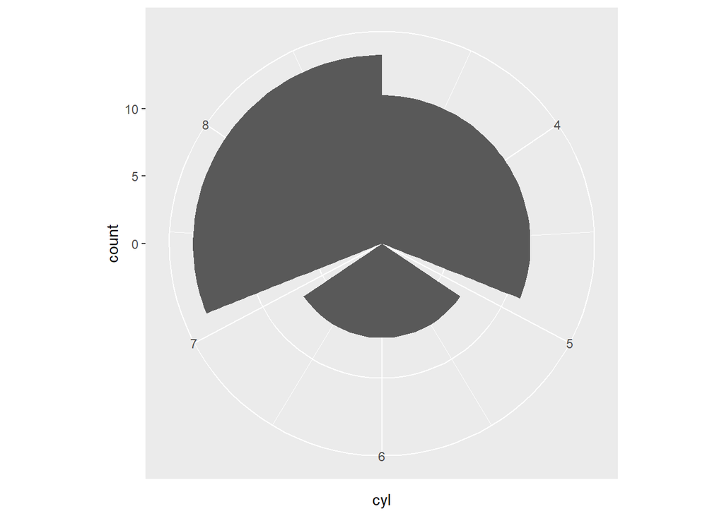

```r
ggplot(data = mtcars, aes(x = cyl)) + geom_bar() + coord_polar()
```

## Темы оформления

По умолчанию графики строятся на сером фоне (theme_grey). Предполагается, что пользователь поместит график в бумажную публикацию и серый фон уравновесит цветовой баланс страницы: цвет бумаги — белый, цвет букв — черный, в среднем цвет страницы — серый.

График на белом фоне будет резко выделяться на странице, но иногда именно это и нужно:

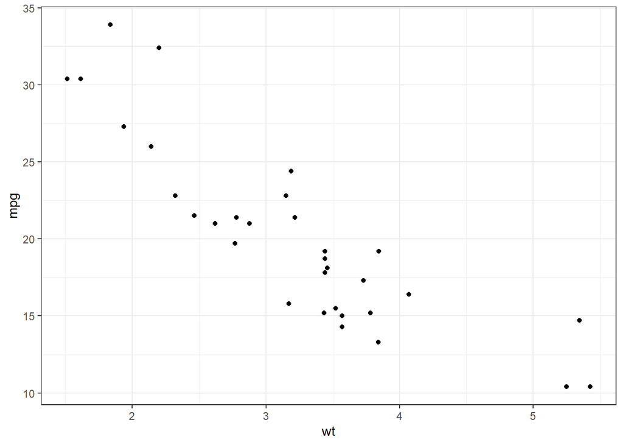

```r
ggplot(data = mtcars, mapping = aes(x = wt, y = mpg)) + geom_point() + theme_bw()
```

theme_bw() — черно-белая тема оформления.

## Рецепты для ggplot2

### Форматирование дат по оси X

Данные из: https://stackoverflow.com/questions/11748384/formatting-dates-on-x-axis-in-ggplot2

```r
df <- data.frame(Month = c("2011-07-31", "2011-08-31", "2011-09-30", "2011-10-31", "2011-11-30", "2011-12-31", "2012-01-31", "2012-02-29", "2012-03-31", "2012-04-30", "2012-05-31", "2012-06-30"), AvgVisits = c(6.99,7.66, 7.70, 7.54, 7.24, 6.32, 6.67, 7.21, 7.60, 6.70, 6.58, 6.75))
knitr::kable(df)
```

| Month | AvgVisits |
| --- | --- |
| 2011-07-31 | 6.99 |
| 2011-08-31 | 7.66 |
| 2011-09-30 | 7.70 |
| 2011-10-31 | 7.54 |
| 2011-11-30 | 7.24 |
| 2011-12-31 | 6.32 |
| 2012-01-31 | 6.67 |
| 2012-02-29 | 7.21 |
| 2012-03-31 | 7.60 |
| 2012-04-30 | 6.70 |
| 2012-05-31 | 6.58 |
| 2012-06-30 | 6.75 |

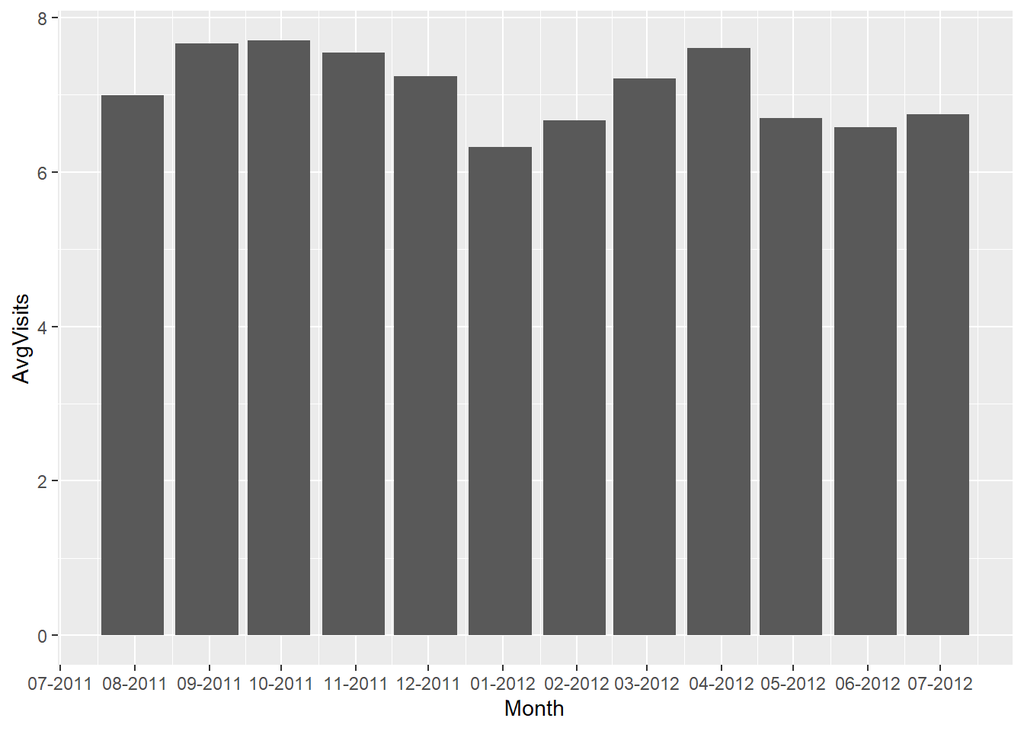

```r
library(ggplot2)
# Делаем даты Date'ами
df$Month <- as.Date(df$Month)
q <- ggplot(df, aes(x = Month, y = AvgVisits)) +
  geom_bar(stat = "identity") +
  scale_x_date(date_breaks = "1 month", date_labels =  "%m-%Y")
q
```

### Поворот текста подписи на 90 град.

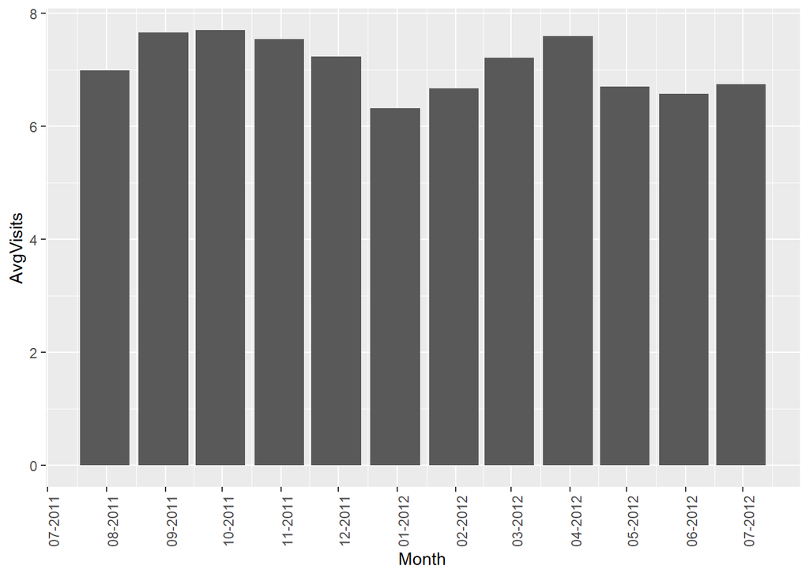

```r
q + theme(axis.text.x = element_text(angle = 90, hjust = 1))
```